# Exercise #3

Fortgeschrittene Statistische Software für NF

Anton Szimmat (12797237)

2025-06-02

## Exercise 1: Initializing git (4 Points)

For this whole exercise sheet we will be tracking all our changes to it in git.

### a)

Start by initializing a new R project with git support, called `2025-exeRcise-sheet-3`. If you forgot how to do this, you can follow this [guide](https://malikaihle.github.io/Introduction-RStudio-Git-GitHub/rstudio_project.html).

### b)

Commit the files generated by Rstudio.

### c)

For all of the following tasks in this exercise sheet we ask you to always commit your changes after finishing each subtask e.g. create a commit after task 1d, 1e etc.

(Note: This applies only to answers that have text or code as their answer. If you complete tasks in a different order or forget to commit one, this is no problem. If you change your answers you can just create multiple commits to track the changes.)

### d)

Name 2 strengths and 2 weaknesses of git. (Don’t forget to create a commit after this answer, see 1c)

- Two Strengths of git
  - Git is really great for collaboration with other users and if you want to understand the changes done by other users
  - Git prevents the user from deleting code or other changes on a files by accident
- Two Weaknesses of git
  - Git often struggles with binary (i.e. non-text) files
  - Git usually struggles with large files (e. g. huge datasets)

### e)

Knit this exercise sheet. Some new files will automatically be generated when knitting the sheet e.g. the HTML page. Ignore these files, as we only want to track the source files themselves. You can, but don’t need to create a `.gitignore` file. Just do not commit these files manually.

- The step in which the source md-document was knitted to html was saved in Git with the commit message “Knitting the Template with exercise 1 finished and using the distill package to html”

## Exercise 2: Putting your Repository on GitHub (3 Points)

For this task you will upload your solution to GitHub.

### a)

Create a new repository on GitHub in your account named `exeRcise-sheet-3`. Make sure you create a **public repository** so we are able to see it for grading. Add the link to the repository below:

- The link to the repository is provided [here](https://github.com/ATSzimmat/exeRcise-sheet-3)

### b)

Push your code to this new repository by copying and executing the snippet on github listed under ” …or push an existing repository from the command line”.

### c)

Regularly push your latest changes to GitHub again and especially do so when you are finished with this sheet.

- Test change that can be pushed to GitHub

## Exercise 3: Pixar Films (4 Points)

Download the `pixar_films` and `public_response` datasets from the GitHub repository and track them in git.

Link: https://github.com/rfordatascience/tidytuesday/tree/main/data/2025/2025-03-11

For small datasets like these adding them to git is not a problem.

### a)

Load the `pixar_films` dataset into R. Clean the dataset by removing films without a title. Inspect the variable `film_rating`. What are the possible values and what do they mean? Create a factor variable for the film rating. Why is this appropriate?

```r
# Loading the dataset into R
library(tidyverse)
pixar_data <- read_csv("data/pixar_films.csv")

# Revoming every film without a title
pixar_data <- pixar_data %>% filter(!is.na(film))

# Gaining insight into to the new dataset
pixar_data %>% head(10)
```

```
## # A tibble: 10 × 5
##    number film            release_date run_time film_rating
##     <dbl> <chr>           <date>          <dbl> <chr>
##  1      1 Toy Story       1995-11-22         81 G
##  2      2 A Bug's Life    1998-11-25         95 G
##  3      3 Toy Story 2     1999-11-24         92 G
##  4      4 Monsters, Inc.  2001-11-02         92 G
##  5      5 Finding Nemo    2003-05-30        100 G
##  6      6 The Incredibles 2004-11-05        115 PG
##  7      7 Cars            2006-06-09        117 G
##  8      8 Ratatouille     2007-06-29        111 G
##  9      9 WALL-E          2008-06-27         98 G
## 10     10 Up              2009-05-29         96 PG
```

```r
# Inspecting the variable film_rating
pixar_data$film_rating
```

```
##  [1] "G"   "G"   "G"   "G"   "G"   "PG"  "G"   "G"   "G"   "PG"  "G"   "G"
## [13] "PG"  "G"   "PG"  "PG"  "PG"  "G"   "PG"  "PG"  "G"   "PG"  "PG"  "N/A"
## [25] "N/A" "N/A"
```

- The variable film_rating shows the suitability of a film for certain audiences based on its content. The possible values are based on the Motion Picture Association (MPA) film rating system.
- There are 5 possible ratings in which the films can be classified (source: https://www.filmratings.com/)
  - “G” (General Audiences) means that all are ages admitted
  - “PG” (Parental Guidance Suggested) means that there is some material in the film that may not be suitable for children
  - “PG-13” (Parents Strongly Cautioned) means that some material in the film may be inappropriate for children under 13
  - “R” (Restricted) means that under 17 requires accompanying parent or adult guardian. The film contains some adult material. Parents are urged to learn more about the film before taking their young children with them
  - “NC-17” (Adults Only) means that the film is suitable only for persons older than 17 years . Children are not admitted

```r
# Checking the type of the variable
typeof(pixar_data$film_rating)
```

```
## [1] "character"
```

```r
# Creating a factor variable for the variable
pixar_data$film_rating <- as.factor(pixar_data$film_rating)
# Checking the type of the variable again
typeof(pixar_data$film_rating)
```

```
## [1] "integer"
```

- This is appropriate because in R a factor variable has a fixed set of possible values and the film rating variable is based on the MPA film rating system which was such afixed set of possible values

### b)

Inspect the film titles manually. Which films form a film series? A film series can be identified by a common word in the titles of the films, often in conjunction with a number in the title, e.g. “Despicable Me” and “Despicable Me 2”. Create a dataframe which displays a list of the different series with the titles of the films and how many films belong to the series. Output the dataframe.

```r
# Loading the tidyverse
library(tidyverse)
# Inspecting the variable film titles
pixar_data$film
```

```
##  [1] "Toy Story"           "A Bug's Life"        "Toy Story 2"
##  [4] "Monsters, Inc."      "Finding Nemo"        "The Incredibles"
##  [7] "Cars"                "Ratatouille"         "WALL-E"
## [10] "Up"                  "Toy Story 3"         "Cars 2"
## [13] "Brave"               "Monsters University" "Inside Out"
## [16] "The Good Dinosaur"   "Finding Dory"        "Cars 3"
## [19] "Coco"                "Incredibles 2"       "Toy Story 4"
## [22] "Onward"              "Soul"                "Luca"
## [25] "Turning Red"         "Lightyear"
```

The following films form a series

```r
# Creating the requested dataframe

# Creating a new variable that displays all the film titles without numbers; also I removed the article "the" from the film names because otherwhise it'll cause troubles
pixar_data_II <- pixar_data%>%
  mutate(film_series = str_remove(film, "^(The)\\s"),
film_series = str_remove(film_series, "\\s\\d+$"))

# Creating a dataframe that displays a list of the different series with the titles of the films and how many films belong to the series
pixar_data_II <- pixar_data_II %>%
  group_by(film_series) %>%
  summarise(
    films = paste(film, collapse = ", "),
    count = n())

# Now the article "the" is added again to two film series
pixar_data_II <- pixar_data_II %>%
                 mutate(film_series = case_when(film_series == "Incredibles" ~
                                  "The Incredibles",
                                  film_series == "Good Dinosaur" ~
                                  "The Good Dinosaur", TRUE ~ film_series))

# Now a small correction ...
pixar_data_II <- pixar_data_II %>%
                 mutate(films = case_when(films == "Finding Nemo" ~
  "Finding Nemo, Finding Dory",
  films == "Monsters, Inc." ~
  "Monsters Inc., Monsters University",
  films == "Toy Story, Toy Story 2, Toy Story 3, Toy Story 4" ~
  "Toy Story, Toy Story 2, Toy Story 3, Toy Story 4, Lightyear", TRUE ~ films)) %>% slice(-c(5, 10, 12))

# Output the first 10 lines of new dataframe
pixar_data_II %>% head(10)
```

```
## # A tibble: 10 × 3
##    film_series       films                              count
##    <chr>             <chr>                              <int>
##  1 A Bug's Life      A Bug's Life                           1
##  2 Brave             Brave                                  1
##  3 Cars              Cars, Cars 2, Cars 3                   3
##  4 Coco              Coco                                   1
##  5 Finding Nemo      Finding Nemo, Finding Dory             1
##  6 The Good Dinosaur The Good Dinosaur                      1
##  7 The Incredibles   The Incredibles, Incredibles 2         2
##  8 Inside Out        Inside Out                             1
##  9 Luca              Luca                                   1
## 10 Monsters, Inc.    Monsters Inc., Monsters University     1
```

```r
# For the next exercises we'll need the table in a different format
pixar_data_III <- pixar_data_II %>% mutate(film_series = case_when(film_series == "Monsters, Inc." ~ "Monsters Inc.", TRUE ~ film_series))
pixar_long <- pixar_data_III %>%
  separate_rows(films, sep = ",\\s*") %>% rename(film = films, series =   film_series) %>% select(series, film)
# Gaining insight into to the new dataset
pixar_long %>% head(10)
```

```
## # A tibble: 10 × 2
##    series            film
##    <chr>             <chr>
##  1 A Bug's Life      A Bug's Life
##  2 Brave             Brave
##  3 Cars              Cars
##  4 Cars              Cars 2
##  5 Cars              Cars 3
##  6 Coco              Coco
##  7 Finding Nemo      Finding Nemo
##  8 Finding Nemo      Finding Dory
##  9 The Good Dinosaur The Good Dinosaur
## 10 The Incredibles   The Incredibles
```

### c)

Load the `public_response` dataframe into R. Convert the `cinema_score` variable into a factor while ensuring the factor levels are defined in ascending order, from the lowest to the highest score. Combine `public_response` with the `pixar_films` dataset using an appropriate merge variable.

```r
# Loading the dataset into R
library(tidyverse)
response_data <- read_csv("data/public_response.csv")

# Checking the type of the cinema_score variable
typeof(response_data$cinema_score)
```

```
## [1] "character"
```

```r
# Defining the grade levels
grade_levels <- c("D-", "D", "D+", "C-", "C", "C+", "B-", "B", "B+", "A-", "A", "A+")

# Converting the cinema_score variable into an ordered factor
response_data$cinema_score <- factor(response_data$cinema_score, levels = grade_levels)

# Sorting the data by cinema_score
response_data <- response_data %>% arrange(cinema_score)

# A small correction
pixar_data <- pixar_data %>% mutate(film = case_when(film == "Monsters, Inc." ~ "Monsters Inc.", TRUE ~ film))
response_data <- response_data %>% mutate(film = case_when(film == "Monsters, Inc." ~ "Monsters Inc.", TRUE ~ film))

# Adding the releasedate

pixar_release <- pixar_data %>% select(film,release_date)
pixar_release_II <- full_join(pixar_long, pixar_release, by = "film")

# Gaining insight into to the modified dataset
response_data %>% head(10)
```

```
## # A tibble: 10 × 5
##    film                rotten_tomatoes metacritic cinema_score critics_choice
##    <chr>                         <dbl>      <dbl> <fct>                 <dbl>
##  1 Cars 2                           40         57 A-                       67
##  2 Onward                           88         61 A-                       79
##  3 Toy Story                       100         95 A                        NA
##  4 A Bug's Life                     92         77 A                        NA
##  5 Cars                             74         73 A                        89
##  6 Ratatouille                      96         96 A                        91
##  7 WALL-E                           95         95 A                        90
##  8 Toy Story 3                      98         92 A                        97
##  9 Brave                            78         69 A                        81
## 10 Monsters University              80         65 A                        79
```

```r
# Combining the pixar_long  and public_response datasets
pixar_and_respnse_data <- full_join(pixar_release_II, response_data, by = "film")

# Gaining insight into to the new dataset
pixar_and_respnse_data %>% head(10)
```

```
## # A tibble: 10 × 7
##    series            film   release_date rotten_tomatoes metacritic cinema_score
##    <chr>             <chr>  <date>                 <dbl>      <dbl> <fct>
##  1 A Bug's Life      A Bug… 1998-11-25                92         77 A
##  2 Brave             Brave  2012-06-22                78         69 A
##  3 Cars              Cars   2006-06-09                74         73 A
##  4 Cars              Cars 2 2011-06-24                40         57 A-
##  5 Cars              Cars 3 2017-06-16                69         59 A
##  6 Coco              Coco   2017-11-22                97         81 A+
##  7 Finding Nemo      Findi… 2003-05-30                99         90 A+
##  8 Finding Nemo      Findi… 2016-06-17                94         77 A
##  9 The Good Dinosaur The G… 2015-11-25                76         66 A
## 10 The Incredibles   The I… 2004-11-05                97         90 A+
## # ℹ 1 more variable: critics_choice <dbl>
```

### d)

Choose one of the variables representing the public response and create a bar plot for the films belonging to a series. Here are the details of the plot: The film series are represented on the x-axis. Your chosen public response variable is displayed on the y-axis. Each film in the series is represented as a separate bar. Bars are grouped by film under their respective series on the x-axis. Order the bars within a series according to the release date of the films. A title and axis labels for context.

- I chose the variable rotten_tomatoes
- In the Rotten Tomatoes rating system, films are awarded a percentage points from 0 to 100. The higher the percentage score, the better it is rated.

```r
# First, the dataset needs to be adjusted a little
pixar_and_respnse_data_II <- pixar_and_respnse_data %>% select(series, film, release_date, rotten_tomatoes)
# The films for which no Rotten Tomatoes rating is available should be removed
pixar_and_respnse_data_II <- pixar_and_respnse_data_II %>% drop_na()
# Ensuring that the films within a series are sorted by release date
pixar_and_respnse_data_II <- pixar_and_respnse_data_II %>% arrange(series, release_date) %>%
 mutate(film = factor(film, levels = unique(film)))
```

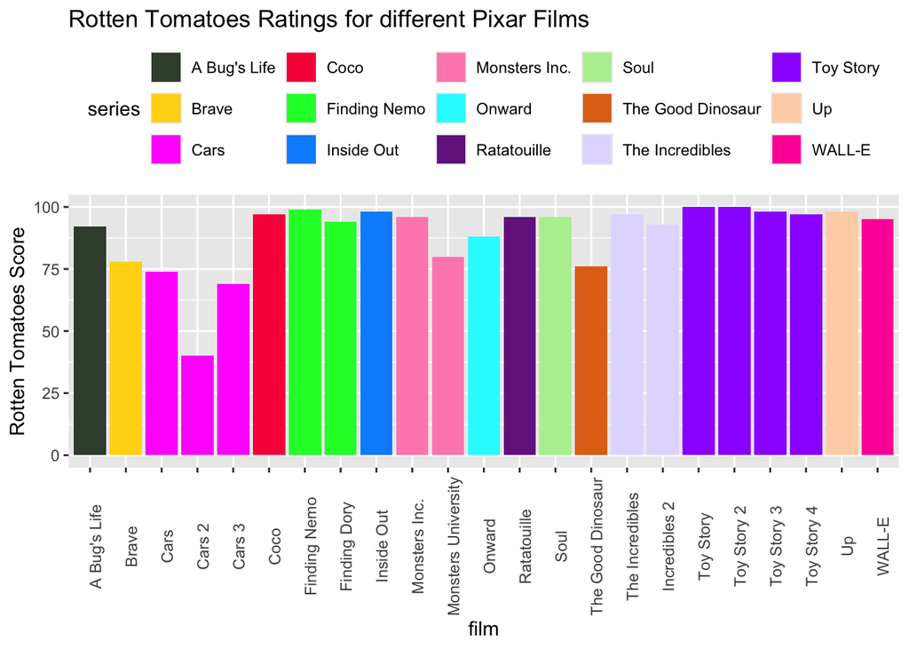

```r
# Generating of a random color palette that is suitable for color-blind people, but also does not represent a color gradient that could impair the readability of the graph
library(Polychrome)
palette_pixar<- createPalette(15, c("#000000", "#FFD700"))
names(palette_pixar) <- unique(pixar_and_respnse_data_II$series)

# Creating the plot; for better readability of the plot, the label of the X axis was rotated by 90 degrees and the legend was moved to the position above the plot
response_plot <- ggplot(pixar_and_respnse_data_II, aes(x = film, y = rotten_tomatoes, fill = series)) +
  geom_bar(stat = "identity") +
  theme(axis.text.x = element_text(angle = 90)) +
  labs(x = "film", y = "Rotten Tomatoes Score", title = "Rotten Tomatoes Ratings for different Pixar Films") +
  theme(legend.position = "top") +
  scale_fill_manual(values = palette_pixar)

response_plot
```

What do you notice when comparing the scores of the films in a series? Do you see any patterns?

- As can be seen in the plot, the individual films in a series received similar ratings (e.g., all Toy Story films received almost 100 percentage points, while all three Cars films performed relatively poorly). Furthermore, it can be observed that in most cases, in a series with multiple films, the sequels always performed worse than their predecessors, and the series thus performed worse as the number of films increased.

## Exercise 4: Open Analysis (4 points)

This exercise is a bit more open-ended. You can choose any dataset from [Our World in Data](https://ourworldindata.org/) and analyze it, while determining the research question yourself.

### a)

Go to https://github.com/owid/owid-datasets/tree/master/datasets and choose a dataset that interests you. You can have a look at https://ourworldindata.org/ to gather some inspiration.

- I have chosen a dataset that shows the proportion of children born outside of marriage per year in different countries

### b)

Download the dataset and track it in git.

```r
# Loading the tidyverse
library(tidyverse)
# I will also load the dataset now into R
birth_data <- read_csv("data/Births outside of marriage.csv")
# Gaining insight into the dataset
birth_data %>% head(10)
```

```
## # A tibble: 10 × 3
##    Entity     Year `Births outside of marriage (% of all births)`
##    <chr>     <dbl>                                          <dbl>
##  1 Australia  1971                                            9.3
##  2 Australia  1974                                            9.5
##  3 Australia  1976                                           10.1
##  4 Australia  1979                                           11.7
##  5 Australia  1980                                           12.4
##  6 Australia  1981                                           13.2
##  7 Australia  1983                                           14.7
##  8 Australia  1984                                           14.8
##  9 Australia  1989                                           20.2
## 10 Australia  1990                                           21.9
```

### c)

Put the name / title of the dataset and a link to it below.

- Dataset Name: Births outside of marriage
- Link: https://github.com/owid/owid-datasets/blob/master/datasets/Births%20outside%20of%20marriage/Births%20outside%20of%20marriage.csv

### d)

Come up with a (research) question you want to answer with the data and briefly explain why you believe this is an interesting question within one sentence. It should be a question that can be answered with the dataset and using R.

### e)

Use R to answer your chosen question. Please limit your analysis to the functions and techniques we have covered so far in the course. You are **not expected** to use advanced statistical models or external packages which haven’t been introduced.

```r
# Data Wrangling

#First, the names should be made more manageable
library(janitor)
birth_data <- birth_data %>% clean_names()

# Since there is not a measurement for every year for every country included in the dataset, the missing years should be filled

# To facilitate this, the data set is first converted to wide format. Moreover the dataset is arranged by year
birth_data_II <- birth_data %>% pivot_wider(names_from = 'entity' ,values_from = births_outside_of_marriage_percent_of_all_births) %>% arrange(year)

# Some countries have a very high number of NAs and are considered not to be sufficiently meaningful for the research question (guideline: if more than 1/3 of the values are NAs)

# Remove columns with too many NAs
threshold <- 1/3
birth_data_III <- birth_data_II %>%
  select(
    year,
    where(~ mean(is.na(.)) <= threshold))
birth_data_III
```

```
## # A tibble: 55 × 30
##     year Austria Belgium Bulgaria Croatia Cyprus `Czech Republic` Denmark
##    <dbl>   <dbl>   <dbl>    <dbl>   <dbl>  <dbl>            <dbl>   <dbl>
##  1  1960    13       2.1      8       7.4   NA                4.9     7.8
##  2  1961    12.6     2        8       7.1    0.3              4.6     8
##  3  1962    12       2.1      8.1     6.5    0.2              4.5     8.3
##  4  1963    11.6     2.2      8.4     6.9    0.1              4.7     8.9
##  5  1964    11.3     2.3      8.8     6.8    0                4.8     9.3
##  6  1965    11.2     2.4      9.4     6      0.1              5       9.5
##  7  1966    11.4     2.5      9.6     5.7    0.1              5.3    10.2
##  8  1967    11.5     2.5      9.7     5.4    0.2              5.3    11.1
##  9  1968    12       2.7      9.6     5.5    0.3              5.4    11.1
## 10  1969    12.2     2.7      9.2     5.6    0.3              5.5    11.3
## # ℹ 45 more rows
## # ℹ 22 more variables: Finland <dbl>, Germany <dbl>, Greece <dbl>,
## #   Hungary <dbl>, Iceland <dbl>, Ireland <dbl>, Italy <dbl>, Latvia <dbl>,
## #   Lithuania <dbl>, Luxembourg <dbl>, Malta <dbl>, Netherlands <dbl>,
## #   `New Zealand` <dbl>, Norway <dbl>, Portugal <dbl>, Slovakia <dbl>,
## #   Slovenia <dbl>, Spain <dbl>, Sweden <dbl>, Switzerland <dbl>,
## #   `United Kingdom` <dbl>, `United States` <dbl>
```

```r
# The remaining NAs are replaced by the value of the previous year or, if this is not available (e.g. if the NA occurred in the oldest measurement year of the data set), by the oldest available value

birth_data_IV <- birth_data_III %>%
  fill(-year, .direction = "down") %>%
  fill(-year, .direction = "up")

# Checking if there are any NAs left
nrow(birth_data_IV) == nrow(birth_data_V <- birth_data_IV %>% drop_na())
```

```
## [1] TRUE
```

```r
# Now the dataset can be converted back to long format
birth_data_VI <- birth_data_IV %>%  pivot_longer(-year, names_to = "country", values_to = "value")

# Gaining insight into the modified dataset
birth_data_VI %>% head(10)
```

```
## # A tibble: 10 × 3
##     year country        value
##    <dbl> <chr>          <dbl>
##  1  1960 Austria         13
##  2  1960 Belgium          2.1
##  3  1960 Bulgaria         8
##  4  1960 Croatia          7.4
##  5  1960 Cyprus           0.3
##  6  1960 Czech Republic   4.9
##  7  1960 Denmark          7.8
##  8  1960 Finland          4
##  9  1960 Germany          7.6
## 10  1960 Greece           1.2
```

```r
# First we have to create a dataset that shows the country with the highest rate of out of marriage births for each year
# If two countries ranked first in this statistic in a year with the same score, both countries will be listed as first place
birth_data_VI_max <- birth_data_VI %>% group_by(year) %>%
                     filter(value == max(value)) %>% ungroup()

# Now we can create a dataset that shows the countries that were most often ranked first in this statistic, in descending order
birth_data_VI_max_II <- birth_data_VI_max %>% group_by(year) %>%
  filter(value == max(value)) %>%
  ungroup() %>%
  count(country, name = "count") %>%
  arrange(desc(count))
# Gaining insight into the final table
birth_data_VI_max_II
```

```
## # A tibble: 2 × 2
##   country count
##   <chr>   <int>
## 1 Iceland    54
## 2 Sweden      3
```

```r
# Now the same steps are being taken for the countries with the lowest rate of children born out of marriage
birth_data_VI_min <- birth_data_VI %>% group_by(year) %>%
                     filter(value == min(value)) %>% ungroup()

birth_data_VI_min_II <- birth_data_VI_min %>% group_by(year) %>%
  filter(value == min(value)) %>%
  ungroup() %>%
  count(country, name = "count") %>%
  arrange(desc(count))
# Gaining insight into the final table
birth_data_VI_min_II
```

```
## # A tibble: 2 × 2
##   country count
##   <chr>   <int>
## 1 Cyprus     46
## 2 Greece      9
```

### f)

Create a meaningful plot / figure with the dataset. Make sure to provide a figure caption (via the chunk options / Rmarkdown) and correctly label the figure

- In this exercise I’ll create a plot which shows the development of rate of out of marriage births for each year in Europe (at least from the European countries included in the dataset and that don’t have too many NAs)
- Since, as shown in the last exercise, Iceland and Sweden had the highest rates across all years included in the data set, these countries should receive special attention in the plot
- To illustrate the development across Europe, we will first calculate the average of the values for all European countries for each year. To highlight the developments in Sweden and Iceland, there should also be calculated an average excluding Sweden and Iceland

```r
# But first the data set needs to be adjusted a bit
library(janitor)
library(tidyverse)
# First, names should be made more manageable
birth_data_VII <- birth_data_IV %>% clean_names()
# Then, all non-European countries should be removed
birth_data_VIII <- birth_data_VII %>% select(-new_zealand)
birth_data_VIII <- birth_data_VIII %>% select(-united_states)
# And finally, some pivotting is necessary
birth_data_VIII <- birth_data_VIII %>%  pivot_longer(-year, names_to = "country", values_to = "value")
# Gaining insight into the modified dataset
birth_data_VIII  %>% head(10)
```

```
## # A tibble: 10 × 3
##     year country        value
##    <dbl> <chr>          <dbl>
##  1  1960 austria         13
##  2  1960 belgium          2.1
##  3  1960 bulgaria         8
##  4  1960 croatia          7.4
##  5  1960 cyprus           0.3
##  6  1960 czech_republic   4.9
##  7  1960 denmark          7.8
##  8  1960 finland          4
##  9  1960 germany          7.6
## 10  1960 greece           1.2
```

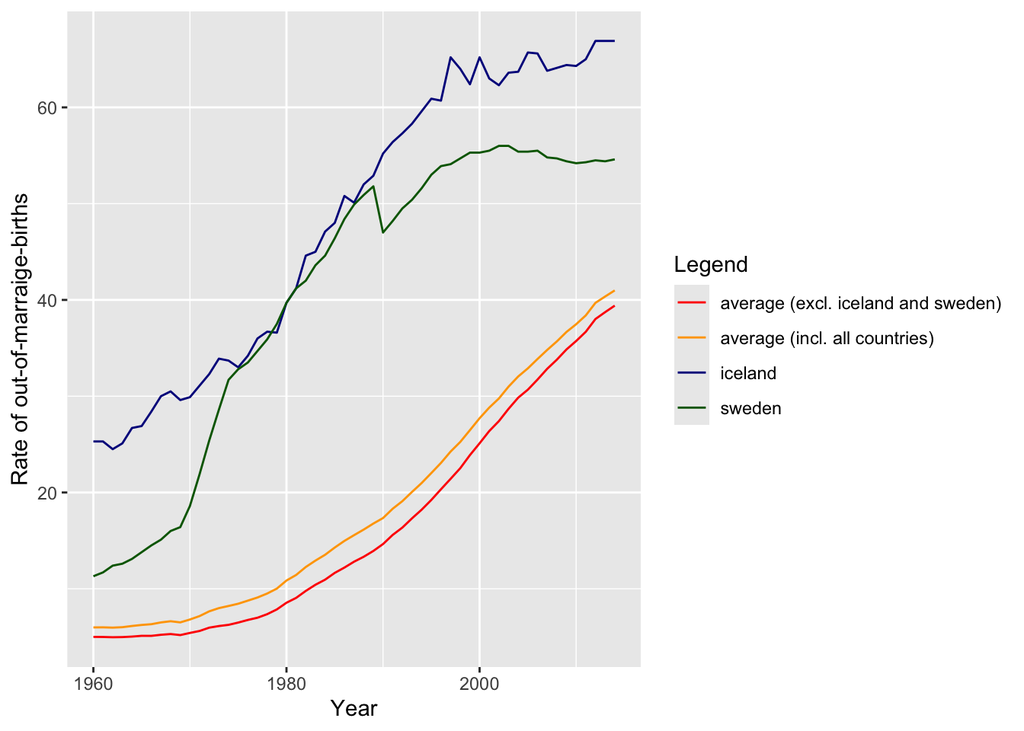

Fig. 1: Rate of out-of-marraige-births in Europe compared to Sweden and Iceland (1960-2014)

```r
# Now the plot will be created
library(tidyverse)

# Calculatung the average of all European countries
birth_data_VIII_avg_all <- birth_data_VIII %>%
  group_by(year) %>%
  summarise(value = mean(value, na.rm = TRUE), .groups = "drop") %>%
  mutate(country = "average (incl. all countries)")

# Calculating the average of all European countries except Iceland and Sweden
birth_data_VIII_avg_excl <- birth_data_VIII %>%
  filter(!country %in% c("iceland", "sweden")) %>%
  group_by(year) %>%
  summarise(value = mean(value, na.rm = TRUE), .groups = "drop") %>%
  mutate(country = "average (excl. iceland and sweden)")

# Calculating values only for Iceland
data_iceland <- birth_data_VIII %>%
  filter(country == "iceland")

# Calculating values only for Sweden
data_sweden <- birth_data_VIII %>%
  filter(country == "sweden")

# Combining all datasets
plot_data <- bind_rows(
  birth_data_VIII_avg_excl,
  birth_data_VIII_avg_all,
  data_iceland,
  data_sweden)

# Creating the plot
ggplot(plot_data, aes(x = year, y = value, color = country)) +
  geom_line() +
  scale_color_manual(values = c(
    "average (excl. iceland and sweden)" = "red",
    "average (incl. all countries)" = "orange",
    "iceland" = "darkblue",
    "sweden" = "darkgreen")) +
  labs(
    x = "Year",
    y = "Rate of out-of-marraige-births",
    color = "Legend")
```

- As you can see in the plot, the values for Sweden and Iceland are consistently above the average for European countries (both with and without Sweden and Iceland).
- While the difference between these two countries’ values and the European average was still quite small in the first years covered by the dataset (especially in Sweden), it rose rapidly, (especially in the 1970s and 1980s), and is still clearly visible in the figures for the 2010s.

## Final Note

Make sure to push all your commits and changes to GitHub before submitting the exercise sheet.